# Logistic Regression

Load the train data set on which ROSE was applied

```r
train_rose <- read.csv("data/train_rose.csv")
test <- read.csv("data/test.csv")
```

Remove the column MOSTYPE.41 created during one-hot encoding because it is redundant.

```r
train_rose  <- subset(train_rose, select = -c(MOSTYPE.41))
test <- subset(test, select = -c(MOSTYPE.41))
```

## Complete model

Fit a logistic regression model using all the variables

```r
complete_model <- glm(
    CARAVAN ~ .,
    data = train_rose,
    family = "binomial"
    )
summary(complete_model)
```

```
##
## Call:
## glm(formula = CARAVAN ~ ., family = "binomial", data = train_rose)
##
## Coefficients:
##               Estimate Std. Error z value Pr(>|z|)
## (Intercept) -7.284e+00  8.414e-01  -8.657  < 2e-16 ***
## MOSTYPE.1    1.908e-01  5.270e+00   0.036 0.971121
## MOSTYPE.2    1.925e+00  3.401e+00   0.566 0.571395
## MOSTYPE.3    3.308e+00  2.979e+00   1.111 0.266706
## MOSTYPE.4   -4.331e+00  3.614e+00  -1.198 0.230748
## MOSTYPE.5    6.037e+00  3.108e+00   1.942 0.052112 .
## MOSTYPE.6   -1.856e-01  5.264e+00  -0.035 0.971870
## MOSTYPE.7   -1.548e+00  3.656e+00  -0.423 0.672068
## MOSTYPE.8    5.322e+00  4.037e+00   1.318 0.187355
## MOSTYPE.9    3.316e+00  1.887e+00   1.757 0.078942 .
## MOSTYPE.10  -5.960e+00  5.179e+00  -1.151 0.249865
## MOSTYPE.11   1.981e+00  3.174e+00   0.624 0.532394
## MOSTYPE.12   7.150e+00  4.233e+00   1.689 0.091167 .
## MOSTYPE.13   2.244e+00  3.121e+00   0.719 0.472105
## MOSTYPE.15  -1.228e+02  9.385e+03  -0.013 0.989563
## MOSTYPE.16  -1.321e+02  4.813e+03  -0.027 0.978113
## MOSTYPE.17  -1.499e+02  6.786e+03  -0.022 0.982379
## MOSTYPE.18  -1.340e+02  4.440e+03  -0.030 0.975932
## MOSTYPE.19  -1.409e+02  1.196e+04  -0.012 0.990596
## MOSTYPE.20   1.101e+01  4.057e+00   2.715 0.006628 **
## MOSTYPE.21  -1.317e+02  5.263e+03  -0.025 0.980030
## MOSTYPE.22   4.834e+00  3.413e+00   1.417 0.156624
## MOSTYPE.23  -7.672e+00  2.756e+00  -2.783 0.005378 **
## MOSTYPE.24   2.616e+00  3.362e+00   0.778 0.436392
## MOSTYPE.25  -1.342e+00  4.660e+00  -0.288 0.773291
## MOSTYPE.26   6.171e+00  5.086e+00   1.213 0.224948
## MOSTYPE.27   7.070e-02  5.026e+00   0.014 0.988778
## MOSTYPE.28  -1.354e+02  3.773e+03  -0.036 0.971364
## MOSTYPE.29  -2.538e+00  2.958e+00  -0.858 0.390979
## MOSTYPE.30   4.012e+00  3.487e+00   1.150 0.250026
## MOSTYPE.31   8.443e+00  4.304e+00   1.961 0.049829 *
## MOSTYPE.32   1.129e+01  4.282e+00   2.637 0.008372 **
## MOSTYPE.33   6.052e+00  2.044e+00   2.961 0.003071 **
## MOSTYPE.34   1.054e+00  3.109e+00   0.339 0.734561
```

[output cut: 55 more lines]

```
## PZEILPL     -1.081e+01  1.444e+01  -0.748 0.454257
## PPLEZIER     8.517e+00  7.970e-01  10.687  < 2e-16 ***
## PFIETS       6.494e+00  1.180e+00   5.506 3.68e-08 ***
## PINBOED     -2.520e-01  1.055e+00  -0.239 0.811247
## PBYSTAND     1.340e+00  4.342e-01   3.086 0.002030 **
## ---
## Signif. codes:  0 '***' 0.001 '**' 0.01 '*' 0.05 '.' 0.1 ' ' 1
##
## (Dispersion parameter for binomial family taken to be 1)
##
##     Null deviance: 15177  on 10947  degrees of freedom
## Residual deviance: 11856  on 10854  degrees of freedom
## AIC: 12044
##
## Number of Fisher Scoring iterations: 15
```

Confusion matrix on the test data set for the complete model

```r
pred <- predict(complete_model, newdata = test, type = "response")
```

ROC curve for the complete model

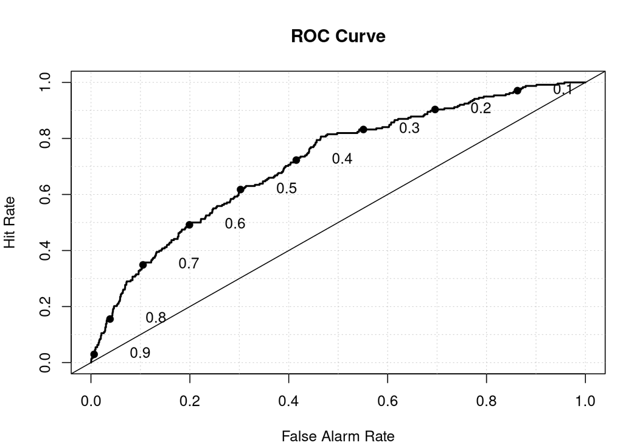

```r
roc.plot(test$CARAVAN, pred)
```

Confusion matrix for the complete model

```r
pred <- ifelse(pred > 0.5, 1, 0)
confusion_matrix <-  confusionMatrix(as.factor(test$CARAVAN), as.factor(pred), positive = "1")
print(confusion_matrix)
```

```
## Confusion Matrix and Statistics
##
##           Reference
## Prediction    0    1
##          0 2623 1139
##          1   91  147
##
##                Accuracy : 0.6925
##                  95% CI : (0.6779, 0.7068)
##     No Information Rate : 0.6785
##     P-Value [Acc > NIR] : 0.02977
##
##                   Kappa : 0.1028
##
##  Mcnemar's Test P-Value : < 2e-16
##
##             Sensitivity : 0.11431
##             Specificity : 0.96647
##          Pos Pred Value : 0.61765
##          Neg Pred Value : 0.69724
##              Prevalence : 0.32150
##          Detection Rate : 0.03675
##    Detection Prevalence : 0.05950
##       Balanced Accuracy : 0.54039
##
##        'Positive' Class : 1
##
```

The model uses all the variables, but some of them may not be significant. We can use the Variance Inflation Factor (VIF) to check for multicollinearity.

## Variance Inflation Factor

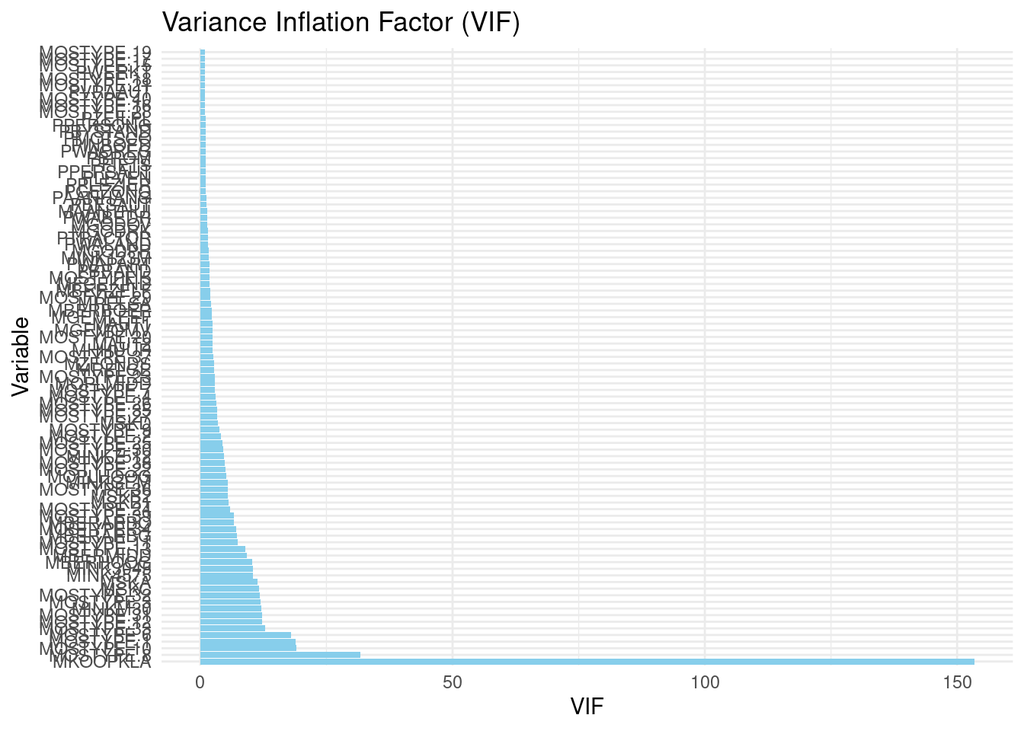

```r
vif_visualizer <- function(model) {
  # Calculate the VIF for the complete model
  vif_values <- vif(model)
  # Create a data frame for plotting
  vif_data <- data.frame(variable = names(vif_values), vif = vif_values)
  # Plot VIF
  ggplot(vif_data, aes(x = reorder(variable, -vif), y = vif)) +
    geom_bar(stat = "identity", fill = "skyblue") +
    coord_flip() +
    labs(title = "Variance Inflation Factor (VIF)",
         x = "Variable",
         y = "VIF") +
    theme_minimal()
}

vif_visualizer(complete_model)
```

The VIF plot shows that are variables that cause multicollinearity. We have to remove some varialbes to reduce the multicollinearity and to make the model model more interpretable.

## Reduced model

We can start by dropping the variables that are likely to be not different from zero and with a very small effect on the response variable. Select the variables that have a p-value less than 0.10 and a coefficient greater than 0.01. This seems to be a good compromise between the number of variables and the model s performance.

```r
vars <- names(which(summary(complete_model)$coefficients[,4] < 0.10 & summary(complete_model)$coefficients[,1] > abs(0.01)))
print(vars)
```

```
##  [1] "MOSTYPE.5"  "MOSTYPE.9"  "MOSTYPE.12" "MOSTYPE.20" "MOSTYPE.31"
##  [6] "MOSTYPE.32" "MOSTYPE.33" "MOSTYPE.36" "MOSTYPE.37" "MOSTYPE.38"
## [11] "MOSTYPE.39" "MGEMLEEF"   "MGODPR"     "MGODOV"     "MRELGE"
## [16] "MOPLHOOG"   "MOPLMIDD"   "MBERHOOG"   "MBERZELF"   "MBERMIDD"
## [21] "MBERARBO"   "MSKC"       "MAUT1"      "MZFONDS"    "PWAPART"
## [26] "PPERSAUT"   "PGEZONG"    "PWAOREG"    "PBRAND"     "PPLEZIER"
## [31] "PFIETS"     "PBYSTAND"
```

Fit a logistic regression model using only the selected variables

```r
vars <- c(vars, "CARAVAN")
reduced_model <- glm(
    CARAVAN ~ .,
    data = train_rose[, vars],
    family = "binomial"
    )
```

```r
summary(reduced_model)
```

```
##
## Call:
## glm(formula = CARAVAN ~ ., family = "binomial", data = train_rose[,
##     vars])
##
## Coefficients:
##             Estimate Std. Error z value Pr(>|z|)
## (Intercept) -6.99614    0.27886 -25.088  < 2e-16 ***
## MOSTYPE.5   -0.26102    2.34437  -0.111 0.911347
## MOSTYPE.9    0.62745    1.02574   0.612 0.540737
## MOSTYPE.12   8.45053    1.27635   6.621 3.57e-11 ***
## MOSTYPE.20   5.56228    2.80399   1.984 0.047289 *
## MOSTYPE.31   3.14675    1.31924   2.385 0.017066 *
## MOSTYPE.32   6.33298    1.30744   4.844 1.27e-06 ***
## MOSTYPE.33   3.09268    0.66211   4.671 3.00e-06 ***
## MOSTYPE.36   6.60397    1.00926   6.543 6.01e-11 ***
## MOSTYPE.37   5.46003    1.25182   4.362 1.29e-05 ***
## MOSTYPE.38   6.39790    0.88727   7.211 5.56e-13 ***
## MOSTYPE.39   5.26467    0.86600   6.079 1.21e-09 ***
## MGEMLEEF     1.05726    0.15562   6.794 1.09e-11 ***
## MGODPR       0.79049    0.13124   6.023 1.71e-09 ***
## MGODOV       0.69377    0.20773   3.340 0.000839 ***
## MRELGE       1.28308    0.13157   9.752  < 2e-16 ***
## MOPLHOOG     2.35188    0.19058  12.340  < 2e-16 ***
## MOPLMIDD     1.16055    0.15592   7.443 9.82e-14 ***
## MBERHOOG     1.62021    0.19440   8.334  < 2e-16 ***
## MBERZELF     1.28708    0.28871   4.458 8.27e-06 ***
## MBERMIDD     1.62549    0.14851  10.945  < 2e-16 ***
## MBERARBO     0.64674    0.15501   4.172 3.02e-05 ***
## MSKC         1.53008    0.16340   9.364  < 2e-16 ***
## MAUT1        0.77277    0.15143   5.103 3.34e-07 ***
## MZFONDS      0.48803    0.14219   3.432 0.000599 ***
## PWAPART      1.67280    0.24246   6.899 5.23e-12 ***
## PPERSAUT     2.11587    0.07388  28.639  < 2e-16 ***
## PGEZONG      1.88023    0.84037   2.237 0.025261 *
## PWAOREG      2.55033    0.44464   5.736 9.71e-09 ***
## PBRAND       0.81606    0.12918   6.317 2.66e-10 ***
## PPLEZIER     7.51139    0.70913  10.592  < 2e-16 ***
## PFIETS       7.46120    1.11801   6.674 2.49e-11 ***
## PBYSTAND     1.85024    0.41066   4.506 6.62e-06 ***
## ---
## Signif. codes:  0 '***' 0.001 '**' 0.01 '*' 0.05 '.' 0.1 ' ' 1
##
## (Dispersion parameter for binomial family taken to be 1)
##
##     Null deviance: 15177  on 10947  degrees of freedom
## Residual deviance: 12380  on 10915  degrees of freedom
## AIC: 12446
##
## Number of Fisher Scoring iterations: 5
```

Confusion matrix on the test data set for the reduced model

```r
pred <- predict(reduced_model, newdata = test, type = "response")
pred <- ifelse(pred > 0.5, 1, 0)
confusion_matrix <- confusionMatrix(as.factor(test$CARAVAN), as.factor(pred), positive = "1")
print(confusion_matrix)
```

```
## Confusion Matrix and Statistics
##
##           Reference
## Prediction    0    1
##          0 2614 1148
##          1   87  151
##
##                Accuracy : 0.6912
##                  95% CI : (0.6767, 0.7055)
##     No Information Rate : 0.6752
##     P-Value [Acc > NIR] : 0.01572
##
##                   Kappa : 0.1066
##
##  Mcnemar's Test P-Value : < 2e-16
##
##             Sensitivity : 0.11624
##             Specificity : 0.96779
##          Pos Pred Value : 0.63445
##          Neg Pred Value : 0.69484
##              Prevalence : 0.32475
##          Detection Rate : 0.03775
##    Detection Prevalence : 0.05950
##       Balanced Accuracy : 0.54202
##
##        'Positive' Class : 1
##
```

We removed 61 variables from the complete model, and the model performance metrics did not change significantly.

## Stepwise regression

Considering the variables of the reduced model, perform a stepwise regression in order to select the best subset of variables. We use the Bayesian Information Criterion (BIC) to select the best model because we have a large number of variables and the BIC penalizes the number of variables in the model more than Akaike Information Criterion.

```r
# Stepwise regression
stepwise_model <- step(
    glm(
        CARAVAN ~ .,
        data = train_rose[, vars],
        family = "binomial",
    ),
    k = log(nrow(train_rose)),
    direction = "both"
)
```

```
## Start:  AIC=12686.44
## CARAVAN ~ MOSTYPE.5 + MOSTYPE.9 + MOSTYPE.12 + MOSTYPE.20 + MOSTYPE.31 +
##     MOSTYPE.32 + MOSTYPE.33 + MOSTYPE.36 + MOSTYPE.37 + MOSTYPE.38 +
##     MOSTYPE.39 + MGEMLEEF + MGODPR + MGODOV + MRELGE + MOPLHOOG +
##     MOPLMIDD + MBERHOOG + MBERZELF + MBERMIDD + MBERARBO + MSKC +
##     MAUT1 + MZFONDS + PWAPART + PPERSAUT + PGEZONG + PWAOREG +
##     PBRAND + PPLEZIER + PFIETS + PBYSTAND
##
##              Df Deviance   AIC
## - MOSTYPE.5   1    12380 12677
## - MOSTYPE.9   1    12380 12678
## - MOSTYPE.20  1    12384 12681
## - PGEZONG     1    12385 12682
## - MOSTYPE.31  1    12385 12683
## <none>             12380 12686
## - MGODOV      1    12391 12688
## - MZFONDS     1    12391 12689
## - MBERARBO    1    12397 12695
## - MOSTYPE.37  1    12399 12696
## - MBERZELF    1    12400 12697
## - MOSTYPE.33  1    12401 12699
## - PBYSTAND    1    12402 12699
## - MOSTYPE.32  1    12403 12700
## - MAUT1       1    12406 12703
## - MGODPR      1    12416 12714
## - MOSTYPE.39  1    12416 12714
## - PWAOREG     1    12419 12716
## - PBRAND      1    12419 12717
## - MOSTYPE.36  1    12422 12720
## - PFIETS      1    12426 12723
## - MOSTYPE.12  1    12426 12724
## - MGEMLEEF    1    12426 12724
## - PWAPART     1    12427 12725
## - MOSTYPE.38  1    12432 12729
## - MOPLMIDD    1    12436 12734
## - MBERHOOG    1    12450 12747
## - MSKC        1    12469 12767
## - MRELGE      1    12476 12774
## - MBERMIDD    1    12502 12799
## - MOPLHOOG    1    12538 12836
```

[output cut: 201 more lines]

```
## - PBRAND      1    12436 12688
## - PWAOREG     1    12436 12688
## - MOSTYPE.12  1    12442 12693
## - PFIETS      1    12443 12694
## - PWAPART     1    12444 12696
## - MGEMLEEF    1    12445 12696
## - MOSTYPE.38  1    12445 12696
## - MOPLMIDD    1    12452 12703
## - MBERHOOG    1    12466 12717
## - MSKC        1    12488 12739
## - MRELGE      1    12498 12749
## - MBERMIDD    1    12516 12767
## - MOPLHOOG    1    12557 12808
## - PPLEZIER    1    12612 12863
## - PPERSAUT    1    13292 13543
```

```r
summary(stepwise_model)
```

```
##
## Call:
## glm(formula = CARAVAN ~ MOSTYPE.12 + MOSTYPE.32 + MOSTYPE.33 +
##     MOSTYPE.36 + MOSTYPE.37 + MOSTYPE.38 + MOSTYPE.39 + MGEMLEEF +
##     MGODPR + MGODOV + MRELGE + MOPLHOOG + MOPLMIDD + MBERHOOG +
##     MBERZELF + MBERMIDD + MBERARBO + MSKC + MAUT1 + MZFONDS +
##     PWAPART + PPERSAUT + PWAOREG + PBRAND + PPLEZIER + PFIETS +
##     PBYSTAND, family = "binomial", data = train_rose[, vars])
##
## Coefficients:
##             Estimate Std. Error z value Pr(>|z|)
## (Intercept)  -6.9608     0.2776 -25.076  < 2e-16 ***
## MOSTYPE.12    8.1891     1.2650   6.474 9.56e-11 ***
## MOSTYPE.32    5.9602     1.2964   4.598 4.27e-06 ***
## MOSTYPE.33    2.7748     0.6401   4.335 1.46e-05 ***
## MOSTYPE.36    6.2345     0.9974   6.251 4.09e-10 ***
## MOSTYPE.37    5.1555     1.2441   4.144 3.42e-05 ***
## MOSTYPE.38    6.0016     0.8699   6.899 5.22e-12 ***
## MOSTYPE.39    4.9035     0.8540   5.742 9.36e-09 ***
## MGEMLEEF      1.0666     0.1551   6.877 6.12e-12 ***
## MGODPR        0.7569     0.1301   5.820 5.89e-09 ***
## MGODOV        0.6795     0.2074   3.276 0.001054 **
## MRELGE        1.2997     0.1308   9.939  < 2e-16 ***
## MOPLHOOG      2.3228     0.1880  12.358  < 2e-16 ***
## MOPLMIDD      1.1310     0.1537   7.359 1.85e-13 ***
## MBERHOOG      1.5922     0.1930   8.252  < 2e-16 ***
## MBERZELF      1.1956     0.2869   4.168 3.08e-05 ***
## MBERMIDD      1.5970     0.1476  10.818  < 2e-16 ***
## MBERARBO      0.6662     0.1532   4.347 1.38e-05 ***
## MSKC          1.5281     0.1624   9.411  < 2e-16 ***
## MAUT1         0.7920     0.1511   5.240 1.60e-07 ***
## MZFONDS       0.5213     0.1412   3.691 0.000223 ***
## PWAPART       1.6655     0.2417   6.890 5.57e-12 ***
## PPERSAUT      2.1258     0.0737  28.844  < 2e-16 ***
## PWAOREG       2.5401     0.4427   5.737 9.63e-09 ***
## PBRAND        0.8054     0.1282   6.281 3.36e-10 ***
## PPLEZIER      7.4079     0.7060  10.492  < 2e-16 ***
## PFIETS        7.4307     1.1148   6.665 2.64e-11 ***
## PBYSTAND      1.9758     0.4082   4.841 1.29e-06 ***
## ---
## Signif. codes:  0 '***' 0.001 '**' 0.01 '*' 0.05 '.' 0.1 ' ' 1
##
## (Dispersion parameter for binomial family taken to be 1)
##
##     Null deviance: 15177  on 10947  degrees of freedom
## Residual deviance: 12397  on 10920  degrees of freedom
## AIC: 12453
##
## Number of Fisher Scoring iterations: 5
```

Confusion matrix on the test data set for the stepwise model

```r
pred <- predict(stepwise_model, newdata = test, type = "response")
```

ROC curve for the stepwise model

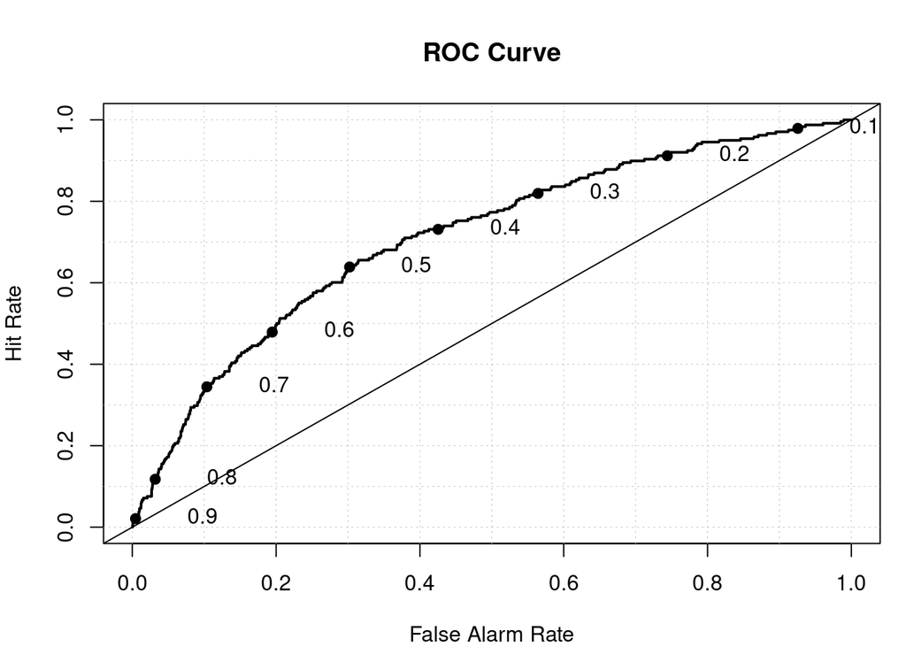

```r
roc.plot(test$CARAVAN, pred)
```

```r
pred <- ifelse(pred > 0.5, 1, 0)
confusion_matrix <- confusionMatrix(as.factor(test$CARAVAN), as.factor(pred), positive = "1")
print(confusion_matrix)
```

```
## Confusion Matrix and Statistics
##
##           Reference
## Prediction    0    1
##          0 2624 1138
##          1   86  152
##
##                Accuracy : 0.694
##                  95% CI : (0.6795, 0.7083)
##     No Information Rate : 0.6775
##     P-Value [Acc > NIR] : 0.01308
##
##                   Kappa : 0.1095
##
##  Mcnemar's Test P-Value : < 2e-16
##
##             Sensitivity : 0.1178
##             Specificity : 0.9683
##          Pos Pred Value : 0.6387
##          Neg Pred Value : 0.6975
##              Prevalence : 0.3225
##          Detection Rate : 0.0380
##    Detection Prevalence : 0.0595
##       Balanced Accuracy : 0.5430
##
##        'Positive' Class : 1
##
```

## Bayesian Information Criterion Summary

Calculate the BIC for the complete, reduced models, and the stepwise model

```r
BIC(complete_model, reduced_model, stepwise_model)
```

```
##                df      BIC
## complete_model 94 12730.39
## reduced_model  33 12686.44
## stepwise_model 28 12657.53
```

## Interpretation and Conclusion

We reached the goal to reduce the number of variables without worsening the model performance.

```
-MOSTYPE.12 Affluent young families

-PPLEZIER Contribution boat policies

-PFIETS Contribution bicycle policies

-MOSTYPE.36 Couples with teens, Married with children

-MOSTYPE.38 Traditional families
```

In particular these vairables have a positive effect on the target variable, meaning that the higher the value of the variable, the higher the probability of the target variable to be 1. The interpretation of the coefficient is note very straightforward because of the encoding and the normalization process applied to the data.